# Untitled

2022-11-04

```r
library(rethinking)
library(rstan)
```

## Question 1

Of these three options, only the third is true. The proposal distribution must be symmetric. If you wanted to use assmyetric proposals then you would have to use either Gibbs sampling or metropolis-hastings.

## Question 2

Gibbs sampling tends to be a bit more efficient because it uses adaptive proposal that relies upon the distribution parameter values adjusting themselves.As 9.2.2 indicates there are some limitations. First, you might not necessarily want to use conjugate pairs, a necessary element of the efficiency. Second, Metropolis and Gibbs but get inefficient when models become complex because they get caught up within small areas of the posterior, potentially missing other parts.

## Question 3

Hamiltonian Monte Carlo can not deal with discrete parameters because the physics simulation it runs requires continuous parameters for the imaginary particle to “glide” over.

## Question 4

N_EFF just references to an estimate of effective samples.This can in certain instances be longer the length of the chain. McElreath argues that the estimate is usually better than raw-number cause they’re misleading. n_eff is almost always smaller than the raw number because the number of samples will always be less than the sheer number of data points.

## Question 5

Rhat should always be approaching 1 from above.

## Question 6

Alrighty, lets create a good trace plot.

First I’m going to have to create a data-set. Let us use a similar one the one in the book

```r
y <- c(-5, 5)

set.seed(1337)
Chaintest1 <- ulam(
  alist(
    y ~ dnorm(mu, sigma),
    mu <- alpha1,
    alpha1 ~ dnorm(0, 2000),
    sigma ~ dexp(0.0001)
  ),
  data = list(y = y), chains = 3, cores = 4
)
```

[output not shown]

```r
y <- c(-5, 5)

set.seed(1337)
Chaintest2 <- ulam(
  alist(
    y ~ dnorm(mu, sigma),
    mu <- alpha1,
    alpha1 ~ dnorm(0, 10),
    sigma ~ dunif(0,1)
  ),
  data = list(y = y), chains = 3, cores = 4
)
```

[output not shown]

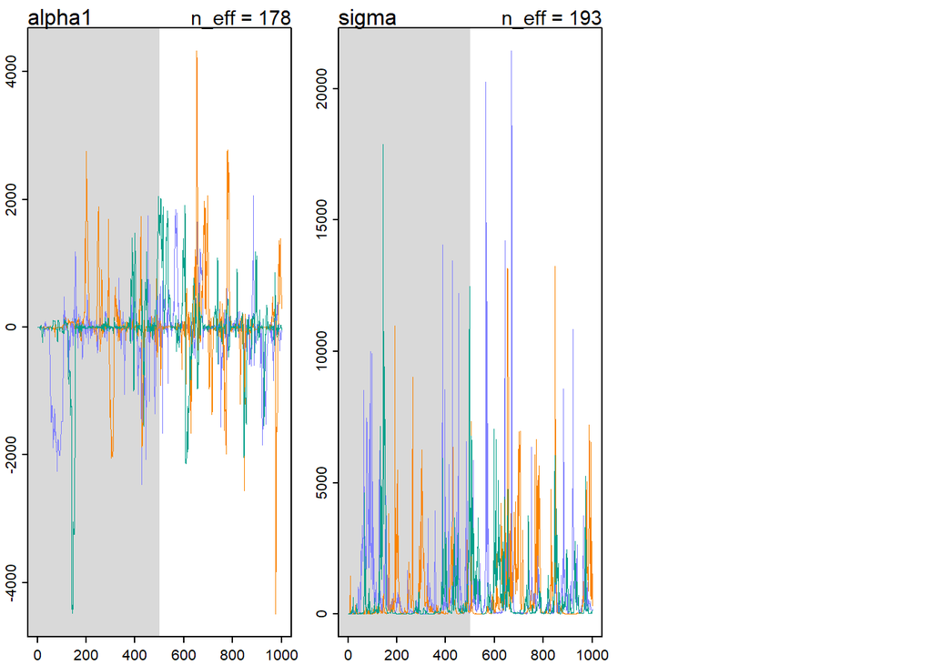

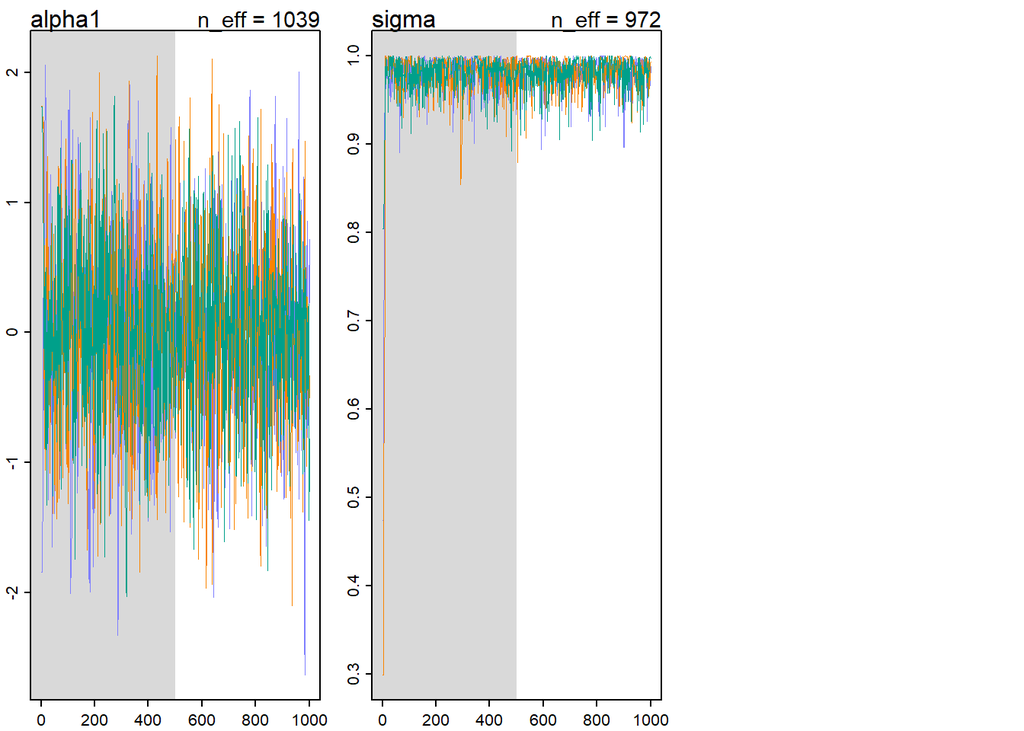

```r
traceplot(Chaintest1)
traceplot(Chaintest2)
```

## Question 7

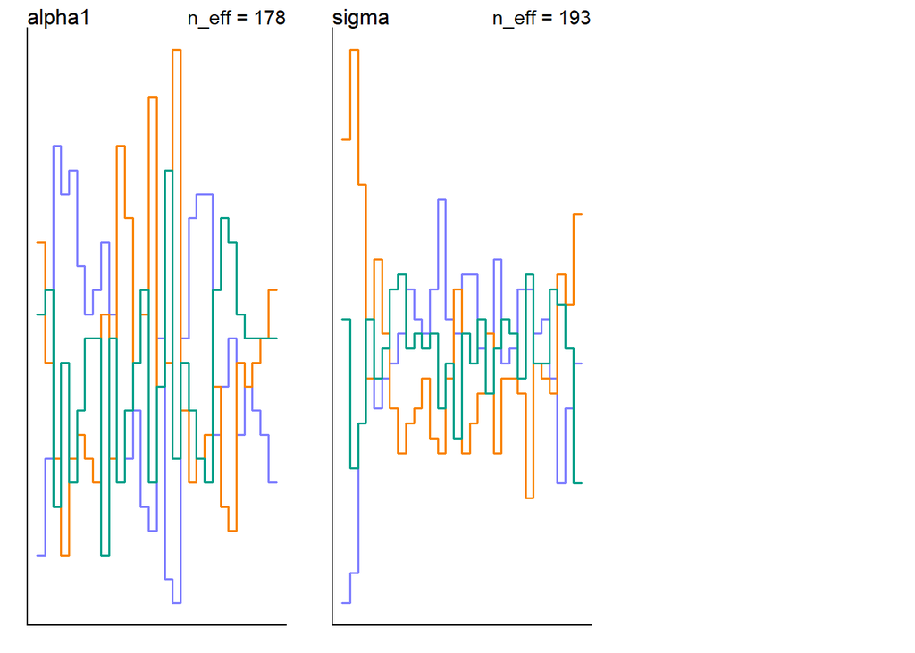

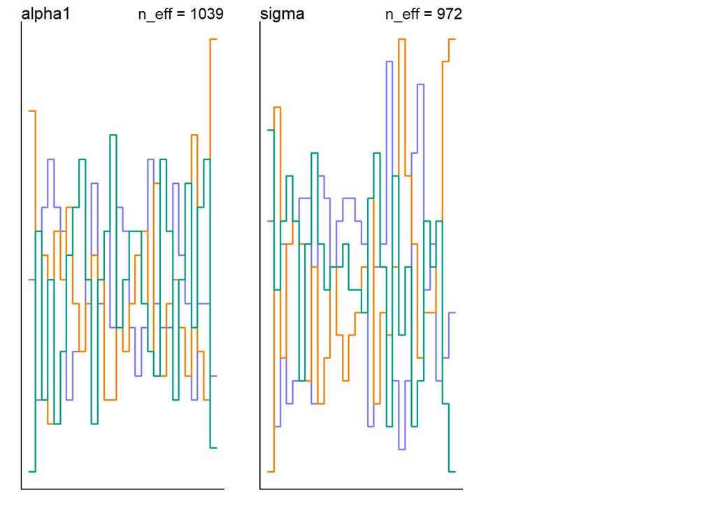

```r
trankplot(Chaintest1)
trankplot(Chaintest2)
```

## Question 1

Lets get the data from the book.

```r
data(rugged)
d <- rugged
d$log_gdp <- log(d$rgdppc_2000)
dd <- d[complete.cases(d$rgdppc_2000) , ]
dd$log_gdp_std <- (dd$log_gdp / mean(dd$log_gdp))

dd$rugged_std <- dd$rugged / max(dd$rugged)
dd$cid <- ifelse( dd$cont_africa==1 , 1 , 2 )
```

Time to slim it down.

```r
dat_slim <- list(
  log_gdp_std = dd$log_gdp_std,
  rugged_std = dd$rugged_std,
  cid = as.integer( dd$cid ) )
str(dat_slim)
```

```
## List of 3
##  $ log_gdp_std: num [1:170] 0.88 0.965 1.166 1.104 0.915 ...
##  $ rugged_std : num [1:170] 0.138 0.553 0.124 0.125 0.433 ...
##  $ cid        : int [1:170] 1 2 2 2 2 2 2 2 2 1 ...
```

Alright, let us take the original version.

```r
Ruggedexp <- ulam(
  alist(
    log_gdp_std ~ dnorm( mu , sigma ) ,
    mu <- a[cid] + b[cid]*( rugged_std - 0.215 ) ,
    a[cid] ~ dnorm( 1 , 0.1 ) ,
    b[cid] ~ dnorm( 0 , 0.3 ) ,
    sigma ~ dexp(1 ) ) ,
  data=dat_slim , chains=4 , cores=4 )
```

[output not shown]

Time to change the sigma to be distributed uniformly.

```r
Rugged9unif <- ulam(
  alist(
    log_gdp_std ~ dnorm( mu , sigma ) ,
    mu <- a[cid] + b[cid]*( rugged_std - 0.215 ) ,
    a[cid] ~ dnorm( 1 , 0.1 ) ,
    b[cid] ~ dnorm( 0 , 0.3 ) ,
    sigma ~ dunif(0, 1 ) ) ,
  data=dat_slim , chains=4 , cores=4 )
```

[output not shown]

lets run it through a precis

```r
precis(Ruggedexp, depth = 2)
```

```
##             mean          sd        5.5%       94.5%    n_eff     Rhat4
## a[1]   0.8864915 0.015854792  0.86151630  0.91173549 2544.882 0.9996218
## a[2]   1.0508351 0.010645098  1.03320780  1.06801055 3693.833 0.9992629
## b[1]   0.1330242 0.072086156  0.01225151  0.24963349 2527.103 0.9996841
## b[2]  -0.1410659 0.057443838 -0.23433244 -0.05166246 2393.125 0.9989110
## sigma  0.1116753 0.006087438  0.10243853  0.12176181 2237.749 1.0020212
```

```r
precis(Rugged9unif, depth = 2)
```

```
##             mean          sd        5.5%      94.5%    n_eff     Rhat4
## a[1]   0.8869420 0.016105731  0.86194744  0.9124752 2935.691 1.0000819
## a[2]   1.0507600 0.010426388  1.03394835  1.0671100 3004.810 0.9988354
## b[1]   0.1344823 0.075292238  0.01444066  0.2538347 2456.301 0.9992568
## b[2]  -0.1430352 0.056090884 -0.23662064 -0.0562159 3006.513 0.9995207
## sigma  0.1117002 0.006247237  0.10230689  0.1223202 2324.466 1.0001180
```

There is seemingly no difference. Indicating the data overran the priors.

## Question 2

Let us change another prior.

```r
Ruggedbcidexp <- ulam(
  alist(
    log_gdp_std ~ dnorm( mu , sigma ) ,
    mu <- a[cid] + b[cid]*( rugged_std - 0.215 ) ,
    a[cid] ~ dnorm( 1 , 0.1 ) ,
    b[cid] ~ dexp(0.3 ) ,
    sigma ~ dexp(1 ) ) ,
  data=dat_slim , chains=4 , cores=4 )
```

[output not shown]

Lets look at it again.

```r
precis(Ruggedbcidexp, depth = 2)
```

```
##             mean          sd       5.5%      94.5%    n_eff     Rhat4
## a[1]  0.88741406 0.015902912 0.86224272 0.91250269 1698.910 0.9992422
## a[2]  1.04814840 0.010502733 1.03189505 1.06459330 1685.870 1.0001420
## b[1]  0.14694601 0.073798745 0.03266794 0.26984558  839.023 1.0016598
## b[2]  0.01873975 0.017960197 0.00108492 0.05343799 1542.820 1.0002277
## sigma 0.11430638 0.006219409 0.10487174 0.12448315 1310.116 1.0012779
```

```r
precis(Ruggedexp, depth = 2)
```

```
##             mean          sd        5.5%       94.5%    n_eff     Rhat4
## a[1]   0.8864915 0.015854792  0.86151630  0.91173549 2544.882 0.9996218
## a[2]   1.0508351 0.010645098  1.03320780  1.06801055 3693.833 0.9992629
## b[1]   0.1330242 0.072086156  0.01225151  0.24963349 2527.103 0.9996841
## b[2]  -0.1410659 0.057443838 -0.23433244 -0.05166246 2393.125 0.9989110
## sigma  0.1116753 0.006087438  0.10243853  0.12176181 2237.749 1.0020212
```

So the difference is pretty clear. it moved the posterior distribution to all positive numbers. This is because the exp function only returns positive values.

## Question 3

I’m going to be a bit lazy here and use the same model i’ve been using.

Let us start with a small number.

```r
Rugged_20 <- ulam(
  alist(
    log_gdp_std ~ dnorm( mu , sigma ) ,
    mu <- a[cid] + b[cid]*( rugged_std - 0.215 ) ,   a[cid] ~ dnorm( 1 , 0.1 ) ,
    b[cid] ~ dnorm( 0 , 0.3 ) ,
    sigma ~ dexp(1 ) ) ,
  data=dat_slim , warmup = 10, iter = 5000, chains=4 , cores=4 )
```

[output not shown]

[output cut: 171 more lines]

```
## Chain 1 Iteration: 4110 / 5000 [ 82%]  (Sampling)
## Chain 1 Iteration: 4210 / 5000 [ 84%]  (Sampling)
## Chain 1 Iteration: 4310 / 5000 [ 86%]  (Sampling)
## Chain 1 Iteration: 4410 / 5000 [ 88%]  (Sampling)
## Chain 1 Iteration: 4510 / 5000 [ 90%]  (Sampling)
## Chain 1 Iteration: 4610 / 5000 [ 92%]  (Sampling)
## Chain 1 Iteration: 4710 / 5000 [ 94%]  (Sampling)
## Chain 1 Iteration: 4810 / 5000 [ 96%]  (Sampling)
## Chain 1 Iteration: 4910 / 5000 [ 98%]  (Sampling)
## Chain 1 Iteration: 5000 / 5000 [100%]  (Sampling)
## Chain 1 finished in 0.9 seconds.
##
## All 4 chains finished successfully.
## Mean chain execution time: 0.5 seconds.
## Total execution time: 1.1 seconds.
```

How about 40?

```r
Rugged_40 <- ulam(
  alist(
    log_gdp_std ~ dnorm( mu , sigma ) ,
    mu <- a[cid] + b[cid]*( rugged_std - 0.215 ) ,   a[cid] ~ dnorm( 1 , 0.1 ) ,
    b[cid] ~ dnorm( 0 , 0.3 ) ,
    sigma ~ dexp(1 ) ) ,
  data=dat_slim , warmup = 40, iter = 5000, chains=4 , cores=4 )
```

[output not shown]

[output cut: 191 more lines]

```
## Chain 3 Iteration: 4940 / 5000 [ 98%]  (Sampling)
## Chain 3 Iteration: 5000 / 5000 [100%]  (Sampling)
## Chain 4 Iteration: 4640 / 5000 [ 92%]  (Sampling)
## Chain 4 Iteration: 4740 / 5000 [ 94%]  (Sampling)
## Chain 4 Iteration: 4840 / 5000 [ 96%]  (Sampling)
## Chain 4 Iteration: 4940 / 5000 [ 98%]  (Sampling)
## Chain 4 Iteration: 5000 / 5000 [100%]  (Sampling)
## Chain 1 finished in 0.8 seconds.
## Chain 2 finished in 0.9 seconds.
## Chain 3 finished in 0.9 seconds.
## Chain 4 finished in 0.9 seconds.
##
## All 4 chains finished successfully.
## Mean chain execution time: 0.9 seconds.
## Total execution time: 1.0 seconds.
```

What about 100?

```r
Rugged_100 <- ulam(
  alist(
    log_gdp_std ~ dnorm( mu , sigma ) ,
    mu <- a[cid] + b[cid]*( rugged_std - 0.215 ) ,   a[cid] ~ dnorm( 1 , 0.1 ) ,
    b[cid] ~ dnorm( 0 , 0.3 ) ,
    sigma ~ dexp(1 ) ) ,
  data=dat_slim , warmup = 100, iter = 5000, chains=4 , cores=4 )
```

[output not shown]

[output cut: 191 more lines]

```
## Chain 2 Iteration: 4600 / 5000 [ 92%]  (Sampling)
## Chain 2 Iteration: 4700 / 5000 [ 94%]  (Sampling)
## Chain 2 Iteration: 4800 / 5000 [ 96%]  (Sampling)
## Chain 2 Iteration: 4900 / 5000 [ 98%]  (Sampling)
## Chain 2 Iteration: 5000 / 5000 [100%]  (Sampling)
## Chain 4 Iteration: 4800 / 5000 [ 96%]  (Sampling)
## Chain 4 Iteration: 4900 / 5000 [ 98%]  (Sampling)
## Chain 4 Iteration: 5000 / 5000 [100%]  (Sampling)
## Chain 1 finished in 0.8 seconds.
## Chain 2 finished in 0.9 seconds.
## Chain 4 finished in 0.8 seconds.
##
## All 4 chains finished successfully.
## Mean chain execution time: 0.8 seconds.
## Total execution time: 1.0 seconds.
```

What about 250?

```r
Rugged_250 <- ulam(
  alist(
    log_gdp_std ~ dnorm( mu , sigma ) ,
    mu <- a[cid] + b[cid]*( rugged_std - 0.215 ) ,   a[cid] ~ dnorm( 1 , 0.1 ) ,
    b[cid] ~ dnorm( 0 , 0.3 ) ,
    sigma ~ dexp(1 ) ) ,
  data=dat_slim , warmup = 250, iter = 5000, chains=4 , cores=4 )
```

[output not shown]

[output cut: 163 more lines]

```
## Chain 4 Iteration: 4750 / 5000 [ 95%]  (Sampling)
## Chain 4 Iteration: 4850 / 5000 [ 97%]  (Sampling)
## Chain 4 Iteration: 4950 / 5000 [ 99%]  (Sampling)
## Chain 4 Iteration: 5000 / 5000 [100%]  (Sampling)
## Chain 1 finished in 0.4 seconds.
## Chain 2 finished in 0.4 seconds.
## Chain 3 Iteration: 4850 / 5000 [ 97%]  (Sampling)
## Chain 3 Iteration: 4950 / 5000 [ 99%]  (Sampling)
## Chain 3 Iteration: 5000 / 5000 [100%]  (Sampling)
## Chain 3 finished in 0.4 seconds.
## Chain 4 finished in 0.4 seconds.
##
## All 4 chains finished successfully.
## Mean chain execution time: 0.4 seconds.
## Total execution time: 0.5 seconds.
```

What about 500?

```r
Rugged500 <- ulam(
  alist(
    log_gdp_std ~ dnorm( mu , sigma ) ,
    mu <- a[cid] + b[cid]*( rugged_std - 0.215 ) ,   a[cid] ~ dnorm( 1 , 0.1 ) ,
    b[cid] ~ dnorm( 0 , 0.3 ) ,
    sigma ~ dexp(1 ) ) ,
  data=dat_slim , warmup = 500, iter = 5000, chains=4 , cores=4 )
```

[output not shown]

[output cut: 163 more lines]

```
## Chain 4 Iteration: 4700 / 5000 [ 94%]  (Sampling)
## Chain 4 Iteration: 4800 / 5000 [ 96%]  (Sampling)
## Chain 4 Iteration: 4900 / 5000 [ 98%]  (Sampling)
## Chain 4 Iteration: 5000 / 5000 [100%]  (Sampling)
## Chain 1 finished in 0.4 seconds.
## Chain 2 Iteration: 5000 / 5000 [100%]  (Sampling)
## Chain 2 finished in 0.4 seconds.
## Chain 3 Iteration: 4900 / 5000 [ 98%]  (Sampling)
## Chain 3 Iteration: 5000 / 5000 [100%]  (Sampling)
## Chain 3 finished in 0.4 seconds.
## Chain 4 finished in 0.4 seconds.
##
## All 4 chains finished successfully.
## Mean chain execution time: 0.4 seconds.
## Total execution time: 0.5 seconds.
```

Why not 1000?

```r
Rugged_1000 <- ulam(
  alist(
    log_gdp_std ~ dnorm( mu , sigma ) ,
    mu <- a[cid] + b[cid]*( rugged_std - 0.215 ) ,   a[cid] ~ dnorm( 1 , 0.1 ) ,
    b[cid] ~ dnorm( 0 , 0.3 ) ,
    sigma ~ dexp(1 ) ) ,
  data=dat_slim , warmup = 1000, iter = 5000, chains=4 , cores=4 )
```

[output not shown]

[output cut: 163 more lines]

```
## Chain 4 Iteration: 4900 / 5000 [ 98%]  (Sampling)
## Chain 4 Iteration: 5000 / 5000 [100%]  (Sampling)
## Chain 1 finished in 0.4 seconds.
## Chain 2 finished in 0.4 seconds.
## Chain 3 Iteration: 4600 / 5000 [ 92%]  (Sampling)
## Chain 3 Iteration: 4700 / 5000 [ 94%]  (Sampling)
## Chain 3 Iteration: 4800 / 5000 [ 96%]  (Sampling)
## Chain 3 Iteration: 4900 / 5000 [ 98%]  (Sampling)
## Chain 3 Iteration: 5000 / 5000 [100%]  (Sampling)
## Chain 3 finished in 0.4 seconds.
## Chain 4 finished in 0.4 seconds.
##
## All 4 chains finished successfully.
## Mean chain execution time: 0.4 seconds.
## Total execution time: 0.5 seconds.
```

Ok, but what about 2500?

```r
Rugged_2500 <- ulam(
  alist(
    log_gdp_std ~ dnorm( mu , sigma ) ,
    mu <- a[cid] + b[cid]*( rugged_std - 0.215 ) ,   a[cid] ~ dnorm( 1 , 0.1 ) ,
    b[cid] ~ dnorm( 0 , 0.3 ) ,
    sigma ~ dexp(1 ) ) ,
  data=dat_slim , warmup = 2500, iter = 5000, chains=4 , cores=4 )
```

[output not shown]

[output cut: 163 more lines]

```
## Chain 4 Iteration: 4400 / 5000 [ 88%]  (Sampling)
## Chain 4 Iteration: 4500 / 5000 [ 90%]  (Sampling)
## Chain 4 Iteration: 4600 / 5000 [ 92%]  (Sampling)
## Chain 4 Iteration: 4700 / 5000 [ 94%]  (Sampling)
## Chain 4 Iteration: 4800 / 5000 [ 96%]  (Sampling)
## Chain 4 Iteration: 4900 / 5000 [ 98%]  (Sampling)
## Chain 1 finished in 0.4 seconds.
## Chain 2 finished in 0.4 seconds.
## Chain 3 finished in 0.4 seconds.
## Chain 4 Iteration: 5000 / 5000 [100%]  (Sampling)
## Chain 4 finished in 0.4 seconds.
##
## All 4 chains finished successfully.
## Mean chain execution time: 0.4 seconds.
## Total execution time: 0.5 seconds.
```

Fuck it, lets do 4000.

```r
Rugged4000 <- ulam(
  alist(
    log_gdp_std ~ dnorm( mu , sigma ) ,
    mu <- a[cid] + b[cid]*( rugged_std - 0.215 ) ,   a[cid] ~ dnorm( 1 , 0.1 ) ,
    b[cid] ~ dnorm( 0 , 0.3 ) ,
    sigma ~ dexp(1 ) ) ,
  data=dat_slim , warmup = 4000, iter = 5000, chains=4 , cores=4 )
```

[output not shown]

[output cut: 163 more lines]

```
## Chain 4 Iteration: 4500 / 5000 [ 90%]  (Sampling)
## Chain 4 Iteration: 4600 / 5000 [ 92%]  (Sampling)
## Chain 4 Iteration: 4700 / 5000 [ 94%]  (Sampling)
## Chain 4 Iteration: 4800 / 5000 [ 96%]  (Sampling)
## Chain 4 Iteration: 4900 / 5000 [ 98%]  (Sampling)
## Chain 4 Iteration: 5000 / 5000 [100%]  (Sampling)
## Chain 1 finished in 0.4 seconds.
## Chain 2 Iteration: 5000 / 5000 [100%]  (Sampling)
## Chain 2 finished in 0.4 seconds.
## Chain 3 finished in 0.4 seconds.
## Chain 4 finished in 0.4 seconds.
##
## All 4 chains finished successfully.
## Mean chain execution time: 0.4 seconds.
## Total execution time: 0.5 seconds.
```

Lets look at these examples.

```r
precis(Rugged_20, depth = 2)
```

```
##             mean          sd        5.5%      94.5%     n_eff    Rhat4
## a[1]   0.8867295 0.016085506  0.86135170  0.9125888 4359.4920 1.000704
## a[2]   1.0504751 0.009799383  1.03473745  1.0660700 2950.9031 1.001959
## b[1]   0.1371903 0.083076468  0.01938897  0.2497856  667.2426 1.007580
## b[2]  -0.1451239 0.067864432 -0.23803135 -0.0522170  580.1946 1.008661
## sigma  0.1113904 0.008036398  0.10193847  0.1219143  719.4461 1.005981
```

```r
precis(Rugged_40, depth = 2)
```

```
##             mean          sd        5.5%       94.5%     n_eff     Rhat4
## a[1]   0.8867561 0.016072098  0.86112473  0.91262370 22175.690 1.0000092
## a[2]   1.0506337 0.010148434  1.03443000  1.06697855 21635.066 0.9999591
## b[1]   0.1321338 0.076188161  0.01056149  0.25478024  8776.148 1.0002326
## b[2]  -0.1434818 0.055941156 -0.23344588 -0.05395079 10759.269 1.0001922
## sigma  0.1115754 0.006198386  0.10209729  0.12186842 11809.193 1.0002539
```

```r
precis(Rugged_100, depth = 2)
```

```
##             mean          sd        5.5%       94.5%     n_eff     Rhat4
## a[1]   0.8866621 0.015895990  0.86118878  0.91223611 20945.544 0.9999760
## a[2]   1.0505056 0.010187278  1.03426945  1.06683000 21107.763 1.0000015
## b[1]   0.1334720 0.075183580  0.01250146  0.25453337  8984.743 1.0003797
## b[2]  -0.1429039 0.055750932 -0.23248439 -0.05368177 12103.440 0.9999077
## sigma  0.1116506 0.006212192  0.10220295  0.12202716 10647.049 1.0000618
```

```r
precis(Rugged_250, depth = 2)
```

```
##             mean          sd        5.5%       94.5%    n_eff     Rhat4
## a[1]   0.8867139 0.015790019  0.86158762  0.91200122 28030.36 0.9998326
## a[2]   1.0505530 0.010167697  1.03421000  1.06665000 27566.26 0.9999047
## b[1]   0.1331963 0.075795958  0.01309162  0.25404733 23600.17 0.9998458
## b[2]  -0.1422853 0.055682299 -0.23122222 -0.05267728 21108.39 0.9999622
## sigma  0.1116034 0.006176412  0.10218189  0.12179706 24290.76 0.9998981
```

```r
precis(Rugged500, depth = 2)
```

```
##             mean          sd       5.5%       94.5%    n_eff     Rhat4
## a[1]   0.8865717 0.015865730  0.8613078  0.91202355 23920.44 0.9998326
## a[2]   1.0505161 0.010075479  1.0344600  1.06663000 29249.04 0.9999557
## b[1]   0.1323126 0.075162167  0.0118917  0.25306716 22118.19 0.9998471
## b[2]  -0.1419618 0.056244398 -0.2313498 -0.05226161 25258.26 0.9999409
## sigma  0.1115565 0.006121127  0.1023000  0.12174005 21675.71 0.9999369
```

```r
precis(Rugged_1000, depth = 2)
```

```
##             mean          sd        5.5%       94.5%    n_eff     Rhat4
## a[1]   0.8867062 0.016039686  0.86103479  0.91246144 20335.59 0.9997875
## a[2]   1.0505179 0.010203017  1.03421000  1.06681110 20694.13 0.9998851
## b[1]   0.1319785 0.075158921  0.01196186  0.25151527 17906.59 1.0000566
## b[2]  -0.1422293 0.056679319 -0.23216370 -0.05157939 19167.03 0.9999336
## sigma  0.1116779 0.006209502  0.10218384  0.12199805 18393.56 0.9999582
```

```r
precis(Rugged_2500, depth = 2)
```

```
##             mean          sd        5.5%      94.5%    n_eff     Rhat4
## a[1]   0.8864830 0.015855135  0.86106700  0.9117971 13760.07 0.9997301
## a[2]   1.0505787 0.010201663  1.03444000  1.0668005 14917.13 0.9998141
## b[1]   0.1321865 0.074768284  0.01341033  0.2505296 13035.97 0.9997414
## b[2]  -0.1430346 0.056652957 -0.23364086 -0.0521768 13579.67 0.9999221
## sigma  0.1116397 0.006112697  0.10230256  0.1218986 13552.84 0.9998653
```

```r
precis(Rugged4000, depth = 2)
```

```
##             mean          sd        5.5%       94.5%    n_eff     Rhat4
## a[1]   0.8863700 0.016063706  0.86040430  0.91242109 5877.872 0.9996802
## a[2]   1.0506037 0.010187653  1.03443780  1.06667110 4886.676 0.9996416
## b[1]   0.1314086 0.073864511  0.01495829  0.24964970 5611.824 0.9992519
## b[2]  -0.1429200 0.056311639 -0.23096096 -0.05227858 6103.084 1.0002915
## sigma  0.1116094 0.006091083  0.10237340  0.12150855 5520.407 0.9995346
```

So the results of this are kind of interesting. 20 warmup is obviously not enough as indicative of the low n_eff and rhat numbers.40 iterations seems solid, but the n_eff numbers for b[1] are still pretty low in this instance. 100 is similar. At 250, you get a pretty decent amount. 1000is relatively similar. Interestingly, 2500 and 4000 tend to have lower n_eff, which makes sense.